# Basic Statistics

Jason Freels

12/19/2019

# Overview

Data analyses involving basic statistical methods can be sub-divided into two main areas - descriptive statistics and inferential statistics. Descriptive statistics use tools like mean and standard deviation on a sample to summarize data. Inferential statistics assumes that data can randomly vary, and then draw conclusions from it.

Today you’ll see how to use Python to implement various methods from both of these areas. It will not be assumed that you have either a) the Python language installed on your machine or b) experience using Python. Rather, you’ll use a cloud based interface to work with the code. In later courses, you’ll learn how to install Python, and any required libraries, on your local machine.

## Descriptive Statistics

Descriptive statistics are measures used to represent data observed from either an entire population or a sample of a population. Descriptive statistics help analysts communicate the features of a specific data set by giving short summaries about the measures of central tendency or the measures of dispersion (variability). Measures of central tendency describe the center position of a distribution for a data set. The most commonly used measures of central tendency include the mean, median, and mode.

Measures of variability, or the measures of spread, aid in analyzing how spread-out the distribution is for a set of data. For example, while a measure of central tendency may describe the average value for a data set, it does not describe how the data is distributed within the set. So, while the average of the data may be 65 out of 100, there can still be data points at both 1 and 100. Measures of variability help communicate this by describing the shape and spread of the data set. the most commonly used measures of variability include the standard deviation, variance, the minimum and maximum variables, and the kurtosis and skewness, Range, quartiles, absolute deviation.

### Measures of Central Tendency

```python
import statistics as st
```

#### [`mean()`](https://docs.python.org/3/library/statistics.html#statistics.mean)

The `mean()` function returns the arithmetic average of a set of numeric values stored in a data object (If called on an empty data object, the function will throw a `StatisticsError`). For the set of values $x_1,x_2, \ldots, x_N$ the mean, denoted by the Greek symbol $\mu$, is calculated as

$$\mu = \frac{\sum_{i = 1}^{N}x_i}{N} = \frac{x_1 + x_2 + \cdots + x_N}{N}.$$

The sample mean gives an unbiased estimate of the true population mean, so when taken on average over all the possible samples, `mean()` converges on the true mean of the entire population. If data represents the entire population rather than a sample, then `mean(data)` is equivalent to calculating the true population mean $\mu$.

In the most simple case, we can create an array of values and find the mean on these values by passing the array to the `mean()` function.

```python
nums = [-2,-4,1,2,3,5,7,9]
st.mean(nums)
```

```
## 2.625
```

```python
Dict = {1:"one",2:"two",3:"three"}

Dict
```

```
## {1: 'one', 2: 'two', 3: 'three'}
```

```python
st.mean(Dict)
```

```
## 2
```

In the code below chunk I create an array or random integers, of length 400, using the `random.randint()` functions

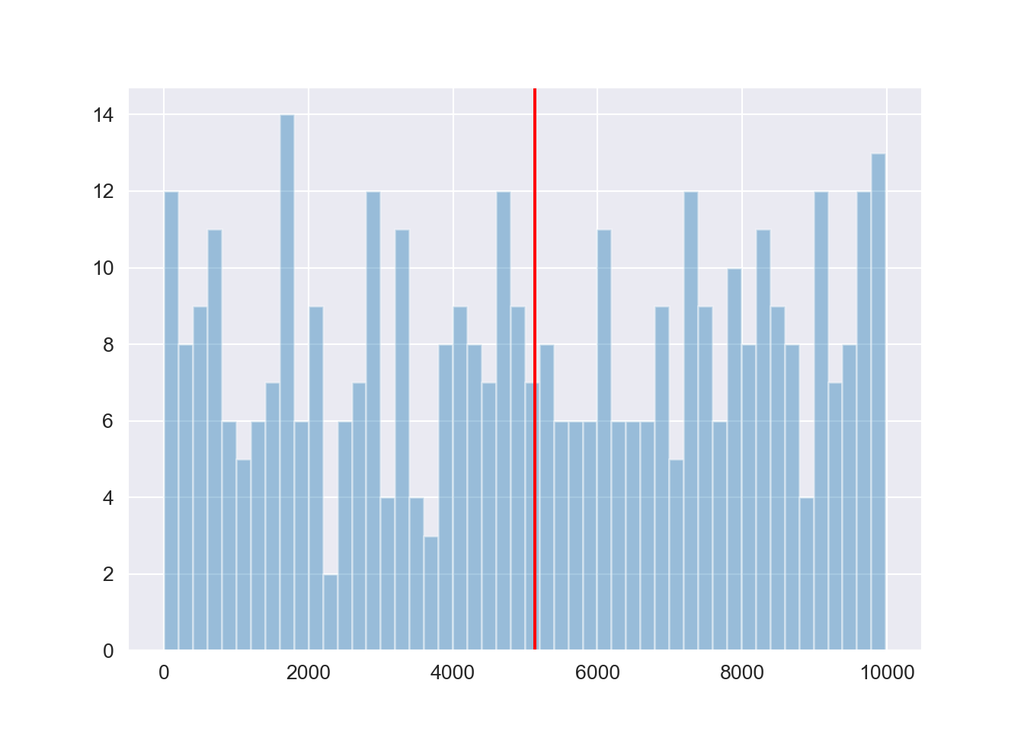

```python
import numpy as np
import seaborn as sb
import matplotlib.pyplot as plt

obs = np.random.randint(low = 1, high = 10000, size = 400)

# Settings
sb.set_style("darkgrid")

# Create histogram
plot = sb.distplot(obs, kde = False, bins = 50)

# add vertical line at mean
plot = plt.axvline(st.mean(obs), 0,1, color = 'red')

plt.show(plot)
```

Note that the mean is strongly affected if the data are skewed (aka non-symmetric). Thus, the mean should not be considered to be a robust estimator of the central location for every set of values. For more robust measures of central location, see the `median()` and `mode()` functions below.

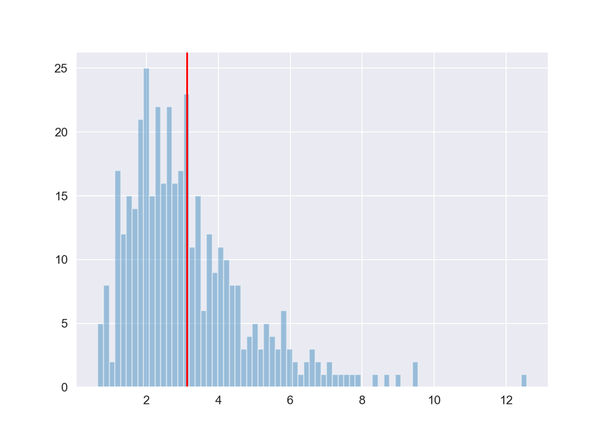

```python
obs2 = np.random.lognormal(mean = 1, sigma = 0.5, size = 400)

# Settings
sb.set_style("darkgrid")

# Create histogram
plot2 = sb.distplot(obs2, kde = False, bins = 75)

# add vertical line at mean
plot2 = plt.axvline(st.mean(obs2), 0,1, color = 'red')

plt.show()
```

#### `mode()`

This function returns the most common value in a set of data. This gives us a great idea of where the center lies.

```python
nums=[1,2,3,5,7,9,7,2,7,6]
st.mode(nums)
```

```
## 7
```

```python
st.mode(['A','B','b','B','A','B'])
```

```
## 'B'
```

#### `median()`

For data of odd length, this returns the middle item; for that of even length, it returns the average of the two middle items.

```python
st.median(nums) #(5+6)/2
```

```
## 5.5
```

#### `harmonic_mean()`

This function returns the harmonic mean of the data. For three values a, b, and c, the harmonic mean is- 3/(1/a + 1/b +1/c) It is a measure of the center; one such example would be speed.

```python
st.harmonic_mean([2,4,9.7])
```

```
## 3.516616314199396
```

For the same set of data, the arithmetic mean would give us a value of 5.233333333333333.

#### `median_low()`

When the data is of an even length, this provides us the low median of the data. Otherwise, it returns the middle value.

```python
st.median_low([1,2,4])
```

```
## 2
```

```python
st.median_low([1,2,3,4])
```

```
## 2
```

#### `median_high()`

Like median_low, this returns the high median when the data is of an even length. Otherwise, it returns the middle value.

```python
st.median_high([1,2,4])
```

```
## 2
```

```python
st.median_high([1,2,3,4])
```

```
## 3
```

#### `median_grouped()`

This function uses interpolation to return the median of grouped continuous data. This is the 50th percentile.

```python
st.median([1,3,3,5,7])
```

```
## 3
```

```python
st.median_grouped([1,3,3,5,7], interval = 1)
```

```
## 3.25
```

```python
st.median_grouped([1,3,3,5,7], interval = 2)
```

```
## 3.5
```

#### `variance()`

This returns the variance of the sample. This is the second moment about the mean and a larger value denotes a rather spread-out set of data. You can use this when your data is a sample out of a population.

```python
st.variance(nums)
```

```
## 7.433333333333334
```

#### `pvariance()`

This returns the population variance of data. Use this to calculate variance from an entire population.

```python
st.pvariance(nums)
```

```
## 6.69
```

#### `stdev()`

This returns the standard deviation for the sample. This is equal to the square root of the sample variance.

```python
st.stdev(nums)
```

```
## 2.7264140062238043
```

#### `pstdev()`

This returns the population standard deviation. This is the square root of population variance.

```python
st.pstdev(nums)
```

```
## 2.5865034312755126
```

The statistics module defines one exception- exception statistics.StatisticsError This is a subclass of ValueError.

#### `pandas` with Descriptive Statistics in Python

We can do the same things using pandas too-

```python
import pandas as pd
```

```python
df=pd.DataFrame(nums)
```

```python
df.mean()
```

```
## 0    4.9
## dtype: float64
```

```python
df.mode()
```

```
##    0
## 0  7
```

```python
df.std() #Standard deviation
```

```
## 0    2.726414
## dtype: float64
```

```python
df.skew()
```

```
## 0   -0.115956
## dtype: float64
```

A value less than -1 is skewed to the left; that greater than 1 is skewed to the right. A value between -1 and 1 is symmetric.